# Risk Factor Analysis

## Outcome Variable

**Outcome Variable:** pers_wasted624

## Predictor Variables

**Intervention Variable:** pers_wasted06

**Adjustment Set:**

- sex
- arm
- enstunt
- month
- brthmon
- vagbrth
- single
- W_gagebrth
- W_birthwt
- W_birthlen
- W_mage
- W_mhtcm
- W_meducyrs
- W_feducyrs
- W_parity
- delta_month
- delta_brthmon
- delta_vagbrth
- delta_single
- delta_W_gagebrth
- delta_W_birthwt
- delta_W_birthlen
- delta_W_mage
- delta_W_mhtcm
- delta_W_meducyrs
- delta_W_feducyrs
- delta_W_parity

## Stratifying Variables

The analysis was stratified on these variable(s):

- studyid
- country

## Data Summary

| studyid | country | pers_wasted06 | pers_wasted624 | n_cell | n |
| --- | --- | --- | --- | --- | --- |
| ki0047075b-MAL-ED | BANGLADESH | 0 | 0 | 218 | 239 |
| ki0047075b-MAL-ED | BANGLADESH | 0 | 1 | 15 | 239 |
| ki0047075b-MAL-ED | BANGLADESH | 1 | 0 | 3 | 239 |
| ki0047075b-MAL-ED | BANGLADESH | 1 | 1 | 3 | 239 |
| ki0047075b-MAL-ED | BRAZIL | 0 | 0 | 200 | 202 |
| ki0047075b-MAL-ED | BRAZIL | 0 | 1 | 1 | 202 |
| ki0047075b-MAL-ED | BRAZIL | 1 | 0 | 0 | 202 |
| ki0047075b-MAL-ED | BRAZIL | 1 | 1 | 1 | 202 |
| ki0047075b-MAL-ED | INDIA | 0 | 0 | 198 | 234 |
| ki0047075b-MAL-ED | INDIA | 0 | 1 | 18 | 234 |
| ki0047075b-MAL-ED | INDIA | 1 | 0 | 8 | 234 |
| ki0047075b-MAL-ED | INDIA | 1 | 1 | 10 | 234 |
| ki0047075b-MAL-ED | NEPAL | 0 | 0 | 229 | 234 |
| ki0047075b-MAL-ED | NEPAL | 0 | 1 | 1 | 234 |
| ki0047075b-MAL-ED | NEPAL | 1 | 0 | 3 | 234 |
| ki0047075b-MAL-ED | NEPAL | 1 | 1 | 1 | 234 |
| ki0047075b-MAL-ED | PERU | 0 | 0 | 262 | 264 |
| ki0047075b-MAL-ED | PERU | 0 | 1 | 2 | 264 |
| ki0047075b-MAL-ED | PERU | 1 | 0 | 0 | 264 |
| ki0047075b-MAL-ED | PERU | 1 | 1 | 0 | 264 |
| ki0047075b-MAL-ED | SOUTH AFRICA | 0 | 0 | 255 | 258 |
| ki0047075b-MAL-ED | SOUTH AFRICA | 0 | 1 | 1 | 258 |
| ki0047075b-MAL-ED | SOUTH AFRICA | 1 | 0 | 1 | 258 |
| ki0047075b-MAL-ED | SOUTH AFRICA | 1 | 1 | 1 | 258 |
| ki0047075b-MAL-ED | TANZANIA, UNITED REPUBLIC OF | 0 | 0 | 244 | 244 |
| ki0047075b-MAL-ED | TANZANIA, UNITED REPUBLIC OF | 0 | 1 | 0 | 244 |
| ki0047075b-MAL-ED | TANZANIA, UNITED REPUBLIC OF | 1 | 0 | 0 | 244 |
| ki0047075b-MAL-ED | TANZANIA, UNITED REPUBLIC OF | 1 | 1 | 0 | 244 |
| ki1000108-CMC-V-BCS-2002 | INDIA | 0 | 0 | 302 | 368 |
| ki1000108-CMC-V-BCS-2002 | INDIA | 0 | 1 | 12 | 368 |

[output cut: 118 more lines]

The following strata were considered:

- studyid: ki0047075b-MAL-ED, country: BANGLADESH
- studyid: ki0047075b-MAL-ED, country: BRAZIL
- studyid: ki0047075b-MAL-ED, country: INDIA
- studyid: ki0047075b-MAL-ED, country: NEPAL
- studyid: ki0047075b-MAL-ED, country: PERU
- studyid: ki0047075b-MAL-ED, country: SOUTH AFRICA
- studyid: ki0047075b-MAL-ED, country: TANZANIA, UNITED REPUBLIC OF
- studyid: ki1000108-CMC-V-BCS-2002, country: INDIA
- studyid: ki1000108-IRC, country: INDIA
- studyid: ki1000109-EE, country: PAKISTAN
- studyid: ki1000109-ResPak, country: PAKISTAN
- studyid: ki1000304-VITAMIN-A, country: INDIA
- studyid: ki1000304b-SAS-CompFeed, country: INDIA
- studyid: ki1000304b-SAS-FoodSuppl, country: INDIA
- studyid: ki1017093-NIH-Birth, country: BANGLADESH
- studyid: ki1017093b-PROVIDE, country: BANGLADESH
- studyid: ki1017093c-NIH-Crypto, country: BANGLADESH
- studyid: ki1066203-TanzaniaChild2, country: TANZANIA, UNITED REPUBLIC OF
- studyid: ki1101329-Keneba, country: GAMBIA
- studyid: ki1112895-Burkina Faso Zn, country: BURKINA FASO
- studyid: ki1112895-Guatemala BSC, country: GUATEMALA
- studyid: ki1113344-GMS-Nepal, country: NEPAL
- studyid: ki1114097-CMIN, country: BANGLADESH
- studyid: ki1114097-CMIN, country: BRAZIL
- studyid: ki1114097-CMIN, country: GUINEA-BISSAU
- studyid: ki1114097-CMIN, country: PERU
- studyid: ki1114097-CONTENT, country: PERU
- studyid: ki1119695-PROBIT, country: BELARUS
- studyid: ki1126311-ZVITAMBO, country: ZIMBABWE
- studyid: ki1135781-COHORTS, country: GUATEMALA
- studyid: ki1135781-COHORTS, country: INDIA
- studyid: ki1135781-COHORTS, country: PHILIPPINES
- studyid: ki1148112-iLiNS-DOSE, country: MALAWI
- studyid: ki1148112-iLiNS-DYAD-M, country: MALAWI
- studyid: ki1148112-LCNI-5, country: MALAWI
- studyid: kiGH5241-JiVitA-3, country: BANGLADESH
- studyid: kiGH5241-JiVitA-4, country: BANGLADESH

### Dropped Strata

Some strata were dropped due to rare outcomes:

- studyid: ki0047075b-MAL-ED, country: BANGLADESH
- studyid: ki0047075b-MAL-ED, country: BRAZIL
- studyid: ki0047075b-MAL-ED, country: NEPAL
- studyid: ki0047075b-MAL-ED, country: PERU
- studyid: ki0047075b-MAL-ED, country: SOUTH AFRICA
- studyid: ki0047075b-MAL-ED, country: TANZANIA, UNITED REPUBLIC OF
- studyid: ki1017093c-NIH-Crypto, country: BANGLADESH
- studyid: ki1112895-Burkina Faso Zn, country: BURKINA FASO
- studyid: ki1112895-Guatemala BSC, country: GUATEMALA
- studyid: ki1114097-CMIN, country: BANGLADESH
- studyid: ki1114097-CMIN, country: BRAZIL
- studyid: ki1114097-CMIN, country: PERU
- studyid: ki1114097-CONTENT, country: PERU
- studyid: ki1148112-iLiNS-DOSE, country: MALAWI
- studyid: ki1148112-iLiNS-DYAD-M, country: MALAWI
- studyid: ki1148112-LCNI-5, country: MALAWI

## Methods Detail

We’re interested in the causal parameters $E[Y_a]$ for all values of $a \in \mathcal{A}$. These parameters represent the mean outcome if, possibly contrary to fact, we intervened to set all units to have $A=a$. Under the randomization and positivity assumptions, these are identified by the statistical parameters $\psi_a=E_W[E_{Y|A,W}(Y|A=a,W)]$. In addition, we’re interested in the mean of $Y$, $E[Y]$ under no intervention (the observed mean). We will estimate these parameters by using SuperLearner to fit the relevant likelihood factors – $E_{Y|A,W}(Y|A=a,W)$ and $p(A=a|W)$, and then updating our likelihood fit using a joint TMLE.

For unadjusted analyses ($W=\{\}$), initial likelihoods were estimated using Lrnr_glm to estimate the simple $E(Y|A)$ and Lrnr_mean to estimate $p(A)$. For adjusted analyses, a small library containing Lrnr_glmnet, Lrnr_xgboost, and Lrnr_mean was used.

Having estimated these parameters, we will then use the delta method to estimate relative risks and attributable risks relative to a prespecified baseline level of $A$.

# Results Detail

## Results Plots

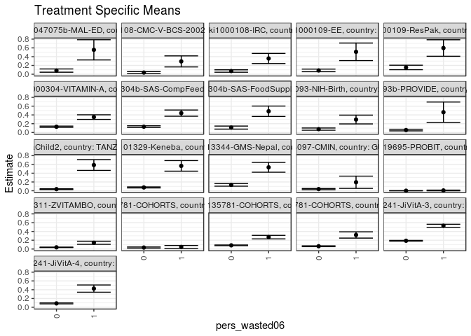

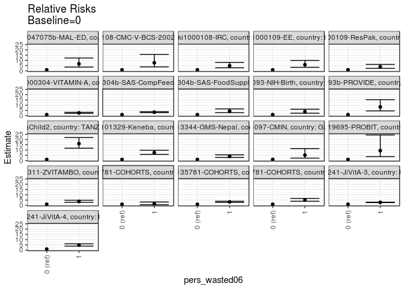

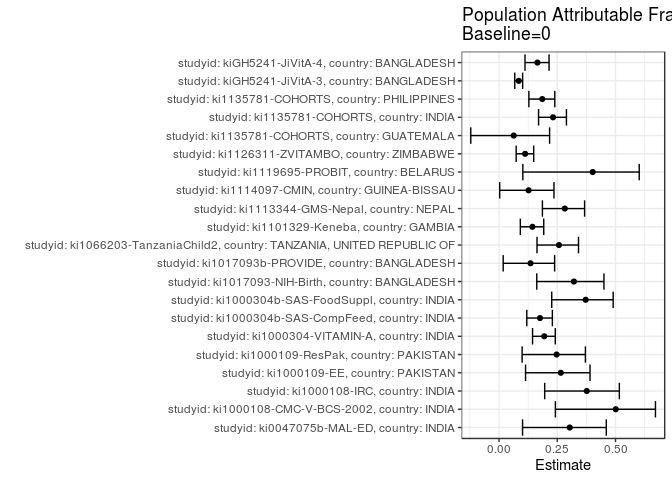

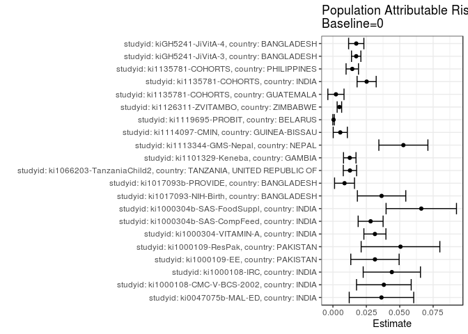

## Results Table

### Parameter: TSM

| studyid | country | intervention_level | baseline_level | estimate | ci_lower | ci_upper |
| --- | --- | --- | --- | --- | --- | --- |
| ki0047075b-MAL-ED | INDIA | 0 | NA | 0.0833333 | 0.0463959 | 0.1202707 |
| ki0047075b-MAL-ED | INDIA | 1 | NA | 0.5555556 | 0.3255098 | 0.7856013 |
| ki1000108-CMC-V-BCS-2002 | INDIA | 0 | NA | 0.0379713 | 0.0166871 | 0.0592554 |
| ki1000108-CMC-V-BCS-2002 | INDIA | 1 | NA | 0.2922232 | 0.1663428 | 0.4181036 |
| ki1000108-IRC | INDIA | 0 | NA | 0.0729939 | 0.0454465 | 0.1005413 |
| ki1000108-IRC | INDIA | 1 | NA | 0.3586480 | 0.2438158 | 0.4734803 |
| ki1000109-EE | PAKISTAN | 0 | NA | 0.0871460 | 0.0572294 | 0.1170627 |
| ki1000109-EE | PAKISTAN | 1 | NA | 0.5104632 | 0.3103083 | 0.7106182 |
| ki1000109-ResPak | PAKISTAN | 0 | NA | 0.1539775 | 0.1030425 | 0.2049125 |
| ki1000109-ResPak | PAKISTAN | 1 | NA | 0.5968080 | 0.4087140 | 0.7849020 |
| ki1000304-VITAMIN-A | INDIA | 0 | NA | 0.1303246 | 0.1154722 | 0.1451770 |
| ki1000304-VITAMIN-A | INDIA | 1 | NA | 0.3505508 | 0.2981815 | 0.4029202 |
| ki1000304b-SAS-CompFeed | INDIA | 0 | NA | 0.1321442 | 0.1123855 | 0.1519029 |
| ki1000304b-SAS-CompFeed | INDIA | 1 | NA | 0.4412594 | 0.3705268 | 0.5119919 |
| ki1000304b-SAS-FoodSuppl | INDIA | 0 | NA | 0.1117178 | 0.0771234 | 0.1463121 |
| ki1000304b-SAS-FoodSuppl | INDIA | 1 | NA | 0.4837772 | 0.3650615 | 0.6024929 |
| ki1017093-NIH-Birth | BANGLADESH | 0 | NA | 0.0768744 | 0.0516333 | 0.1021155 |
| ki1017093-NIH-Birth | BANGLADESH | 1 | NA | 0.2951902 | 0.1947976 | 0.3955828 |
| ki1017093b-PROVIDE | BANGLADESH | 0 | NA | 0.0554622 | 0.0369881 | 0.0739363 |
| ki1017093b-PROVIDE | BANGLADESH | 1 | NA | 0.4615385 | 0.2295775 | 0.6934994 |
| ki1066203-TanzaniaChild2 | TANZANIA, UNITED REPUBLIC OF | 0 | NA | 0.0367208 | 0.0281738 | 0.0452678 |
| ki1066203-TanzaniaChild2 | TANZANIA, UNITED REPUBLIC OF | 1 | NA | 0.5859712 | 0.4636003 | 0.7083422 |
| ki1101329-Keneba | GAMBIA | 0 | NA | 0.0753190 | 0.0640815 | 0.0865565 |
| ki1101329-Keneba | GAMBIA | 1 | NA | 0.5663456 | 0.4461138 | 0.6865774 |
| ki1113344-GMS-Nepal | NEPAL | 0 | NA | 0.1339191 | 0.1044552 | 0.1633829 |
| ki1113344-GMS-Nepal | NEPAL | 1 | NA | 0.5336300 | 0.4219352 | 0.6453247 |
| ki1114097-CMIN | GUINEA-BISSAU | 0 | NA | 0.0377358 | 0.0249030 | 0.0505687 |
| ki1114097-CMIN | GUINEA-BISSAU | 1 | NA | 0.1935484 | 0.0543935 | 0.3327032 |
| ki1119695-PROBIT | BELARUS | 0 | NA | 0.0007270 | 0.0001693 | 0.0012847 |
| ki1119695-PROBIT | BELARUS | 1 | NA | 0.0068285 | -0.0005804 | 0.0142374 |
| ki1126311-ZVITAMBO | ZIMBABWE | 0 | NA | 0.0383709 | 0.0341859 | 0.0425558 |
| ki1126311-ZVITAMBO | ZIMBABWE | 1 | NA | 0.1422555 | 0.1070348 | 0.1774762 |
| ki1135781-COHORTS | GUATEMALA | 0 | NA | 0.0334225 | 0.0205347 | 0.0463102 |
| ki1135781-COHORTS | GUATEMALA | 1 | NA | 0.0469799 | 0.0129857 | 0.0809740 |
| ki1135781-COHORTS | INDIA | 0 | NA | 0.0835431 | 0.0757098 | 0.0913763 |
| ki1135781-COHORTS | INDIA | 1 | NA | 0.2709032 | 0.2311581 | 0.3106482 |
| ki1135781-COHORTS | PHILIPPINES | 0 | NA | 0.0635281 | 0.0541258 | 0.0729304 |
| ki1135781-COHORTS | PHILIPPINES | 1 | NA | 0.3199475 | 0.2488524 | 0.3910426 |
| kiGH5241-JiVitA-3 | BANGLADESH | 0 | NA | 0.1882427 | 0.1803276 | 0.1961579 |
| kiGH5241-JiVitA-3 | BANGLADESH | 1 | NA | 0.5292645 | 0.4946206 | 0.5639085 |
| kiGH5241-JiVitA-4 | BANGLADESH | 0 | NA | 0.0884241 | 0.0778419 | 0.0990062 |
| kiGH5241-JiVitA-4 | BANGLADESH | 1 | NA | 0.4257431 | 0.3435203 | 0.5079660 |

### Parameter: E(Y)

| studyid | country | intervention_level | baseline_level | estimate | ci_lower | ci_upper |
| --- | --- | --- | --- | --- | --- | --- |
| ki0047075b-MAL-ED | INDIA | NA | NA | 0.1196581 | 0.0779840 | 0.1613323 |
| ki1000108-CMC-V-BCS-2002 | INDIA | NA | NA | 0.0760870 | 0.0489610 | 0.1032130 |
| ki1000108-IRC | INDIA | NA | NA | 0.1170732 | 0.0859146 | 0.1482317 |
| ki1000109-EE | PAKISTAN | NA | NA | 0.1185984 | 0.0856546 | 0.1515422 |
| ki1000109-ResPak | PAKISTAN | NA | NA | 0.2045455 | 0.1511224 | 0.2579685 |
| ki1000304-VITAMIN-A | INDIA | NA | NA | 0.1617391 | 0.1466878 | 0.1767905 |
| ki1000304b-SAS-CompFeed | INDIA | NA | NA | 0.1603563 | 0.1395035 | 0.1812092 |
| ki1000304b-SAS-FoodSuppl | INDIA | NA | NA | 0.1778351 | 0.1397389 | 0.2159312 |
| ki1017093-NIH-Birth | BANGLADESH | NA | NA | 0.1132813 | 0.0858017 | 0.1407608 |
| ki1017093b-PROVIDE | BANGLADESH | NA | NA | 0.0641447 | 0.0446535 | 0.0836359 |
| ki1066203-TanzaniaChild2 | TANZANIA, UNITED REPUBLIC OF | NA | NA | 0.0494534 | 0.0397554 | 0.0591514 |
| ki1101329-Keneba | GAMBIA | NA | NA | 0.0879121 | 0.0760335 | 0.0997906 |
| ki1113344-GMS-Nepal | NEPAL | NA | NA | 0.1866438 | 0.1550166 | 0.2182711 |
| ki1114097-CMIN | GUINEA-BISSAU | NA | NA | 0.0432309 | 0.0297785 | 0.0566834 |
| ki1119695-PROBIT | BELARUS | NA | NA | 0.0012159 | 0.0002433 | 0.0021885 |
| ki1126311-ZVITAMBO | ZIMBABWE | NA | NA | 0.0432128 | 0.0388939 | 0.0475316 |
| ki1135781-COHORTS | GUATEMALA | NA | NA | 0.0356745 | 0.0235298 | 0.0478191 |
| ki1135781-COHORTS | INDIA | NA | NA | 0.1087695 | 0.1008135 | 0.1167256 |
| ki1135781-COHORTS | PHILIPPINES | NA | NA | 0.0780116 | 0.0679971 | 0.0880261 |
| kiGH5241-JiVitA-3 | BANGLADESH | NA | NA | 0.2056528 | 0.1980793 | 0.2132263 |
| kiGH5241-JiVitA-4 | BANGLADESH | NA | NA | 0.1058706 | 0.0951082 | 0.1166330 |

### Parameter: RR

| studyid | country | intervention_level | baseline_level | estimate | ci_lower | ci_upper |
| --- | --- | --- | --- | --- | --- | --- |
| ki0047075b-MAL-ED | INDIA | 0 | 0 | 1.000000 | 1.0000000 | 1.000000 |
| ki0047075b-MAL-ED | INDIA | 1 | 0 | 6.666667 | 3.6347655 | 12.227596 |
| ki1000108-CMC-V-BCS-2002 | INDIA | 0 | 0 | 1.000000 | 1.0000000 | 1.000000 |
| ki1000108-CMC-V-BCS-2002 | INDIA | 1 | 0 | 7.695901 | 3.7908163 | 15.623782 |
| ki1000108-IRC | INDIA | 0 | 0 | 1.000000 | 1.0000000 | 1.000000 |
| ki1000108-IRC | INDIA | 1 | 0 | 4.913399 | 2.9910764 | 8.071171 |
| ki1000109-EE | PAKISTAN | 0 | 0 | 1.000000 | 1.0000000 | 1.000000 |
| ki1000109-EE | PAKISTAN | 1 | 0 | 5.857561 | 3.4748969 | 9.873967 |
| ki1000109-ResPak | PAKISTAN | 0 | 0 | 1.000000 | 1.0000000 | 1.000000 |
| ki1000109-ResPak | PAKISTAN | 1 | 0 | 3.875942 | 2.4516496 | 6.127681 |
| ki1000304-VITAMIN-A | INDIA | 0 | 0 | 1.000000 | 1.0000000 | 1.000000 |
| ki1000304-VITAMIN-A | INDIA | 1 | 0 | 2.689828 | 2.2303313 | 3.243991 |
| ki1000304b-SAS-CompFeed | INDIA | 0 | 0 | 1.000000 | 1.0000000 | 1.000000 |
| ki1000304b-SAS-CompFeed | INDIA | 1 | 0 | 3.339227 | 2.9639571 | 3.762011 |
| ki1000304b-SAS-FoodSuppl | INDIA | 0 | 0 | 1.000000 | 1.0000000 | 1.000000 |
| ki1000304b-SAS-FoodSuppl | INDIA | 1 | 0 | 4.330352 | 2.9109737 | 6.441812 |
| ki1017093-NIH-Birth | BANGLADESH | 0 | 0 | 1.000000 | 1.0000000 | 1.000000 |
| ki1017093-NIH-Birth | BANGLADESH | 1 | 0 | 3.839901 | 2.3911857 | 6.166330 |
| ki1017093b-PROVIDE | BANGLADESH | 0 | 0 | 1.000000 | 1.0000000 | 1.000000 |
| ki1017093b-PROVIDE | BANGLADESH | 1 | 0 | 8.321678 | 4.5536120 | 15.207780 |
| ki1066203-TanzaniaChild2 | TANZANIA, UNITED REPUBLIC OF | 0 | 0 | 1.000000 | 1.0000000 | 1.000000 |
| ki1066203-TanzaniaChild2 | TANZANIA, UNITED REPUBLIC OF | 1 | 0 | 15.957481 | 11.6723339 | 21.815790 |
| ki1101329-Keneba | GAMBIA | 0 | 0 | 1.000000 | 1.0000000 | 1.000000 |
| ki1101329-Keneba | GAMBIA | 1 | 0 | 7.519293 | 5.8008382 | 9.746828 |
| ki1113344-GMS-Nepal | NEPAL | 0 | 0 | 1.000000 | 1.0000000 | 1.000000 |
| ki1113344-GMS-Nepal | NEPAL | 1 | 0 | 3.984720 | 2.9478149 | 5.386361 |
| ki1114097-CMIN | GUINEA-BISSAU | 0 | 0 | 1.000000 | 1.0000000 | 1.000000 |
| ki1114097-CMIN | GUINEA-BISSAU | 1 | 0 | 5.129032 | 2.3153952 | 11.361763 |
| ki1119695-PROBIT | BELARUS | 0 | 0 | 1.000000 | 1.0000000 | 1.000000 |
| ki1119695-PROBIT | BELARUS | 1 | 0 | 9.392951 | 3.6435746 | 24.214551 |
| ki1126311-ZVITAMBO | ZIMBABWE | 0 | 0 | 1.000000 | 1.0000000 | 1.000000 |
| ki1126311-ZVITAMBO | ZIMBABWE | 1 | 0 | 3.707385 | 2.8288935 | 4.858684 |
| ki1135781-COHORTS | GUATEMALA | 0 | 0 | 1.000000 | 1.0000000 | 1.000000 |
| ki1135781-COHORTS | GUATEMALA | 1 | 0 | 1.405638 | 0.6191362 | 3.191248 |
| ki1135781-COHORTS | INDIA | 0 | 0 | 1.000000 | 1.0000000 | 1.000000 |
| ki1135781-COHORTS | INDIA | 1 | 0 | 3.242677 | 2.7262702 | 3.856902 |
| ki1135781-COHORTS | PHILIPPINES | 0 | 0 | 1.000000 | 1.0000000 | 1.000000 |
| ki1135781-COHORTS | PHILIPPINES | 1 | 0 | 5.036318 | 3.8608087 | 6.569737 |
| kiGH5241-JiVitA-3 | BANGLADESH | 0 | 0 | 1.000000 | 1.0000000 | 1.000000 |
| kiGH5241-JiVitA-3 | BANGLADESH | 1 | 0 | 2.811606 | 2.6027731 | 3.037195 |
| kiGH5241-JiVitA-4 | BANGLADESH | 0 | 0 | 1.000000 | 1.0000000 | 1.000000 |
| kiGH5241-JiVitA-4 | BANGLADESH | 1 | 0 | 4.814788 | 3.8406047 | 6.036076 |

### Parameter: PAR

| studyid | country | intervention_level | baseline_level | estimate | ci_lower | ci_upper |
| --- | --- | --- | --- | --- | --- | --- |
| ki0047075b-MAL-ED | INDIA | 0 | NA | 0.0363248 | 0.0121946 | 0.0604550 |
| ki1000108-CMC-V-BCS-2002 | INDIA | 0 | NA | 0.0381157 | 0.0176547 | 0.0585766 |
| ki1000108-IRC | INDIA | 0 | NA | 0.0440793 | 0.0226458 | 0.0655128 |
| ki1000109-EE | PAKISTAN | 0 | NA | 0.0314523 | 0.0133732 | 0.0495315 |
| ki1000109-ResPak | PAKISTAN | 0 | NA | 0.0505679 | 0.0211235 | 0.0800123 |
| ki1000304-VITAMIN-A | INDIA | 0 | NA | 0.0314145 | 0.0231695 | 0.0396595 |
| ki1000304b-SAS-CompFeed | INDIA | 0 | NA | 0.0282122 | 0.0188785 | 0.0375459 |
| ki1000304b-SAS-FoodSuppl | INDIA | 0 | NA | 0.0661173 | 0.0397742 | 0.0924604 |
| ki1017093-NIH-Birth | BANGLADESH | 0 | NA | 0.0364068 | 0.0182947 | 0.0545189 |
| ki1017093b-PROVIDE | BANGLADESH | 0 | NA | 0.0086826 | 0.0012208 | 0.0161443 |
| ki1066203-TanzaniaChild2 | TANZANIA, UNITED REPUBLIC OF | 0 | NA | 0.0127326 | 0.0077446 | 0.0177206 |
| ki1101329-Keneba | GAMBIA | 0 | NA | 0.0125931 | 0.0079231 | 0.0172631 |
| ki1113344-GMS-Nepal | NEPAL | 0 | NA | 0.0527248 | 0.0343765 | 0.0710730 |
| ki1114097-CMIN | GUINEA-BISSAU | 0 | NA | 0.0054951 | 0.0002127 | 0.0107775 |
| ki1119695-PROBIT | BELARUS | 0 | NA | 0.0004889 | -0.0000743 | 0.0010521 |
| ki1126311-ZVITAMBO | ZIMBABWE | 0 | NA | 0.0048419 | 0.0031548 | 0.0065290 |
| ki1135781-COHORTS | GUATEMALA | 0 | NA | 0.0022520 | -0.0037959 | 0.0083000 |
| ki1135781-COHORTS | INDIA | 0 | NA | 0.0252265 | 0.0180795 | 0.0323735 |
| ki1135781-COHORTS | PHILIPPINES | 0 | NA | 0.0144836 | 0.0098398 | 0.0191273 |
| kiGH5241-JiVitA-3 | BANGLADESH | 0 | NA | 0.0174101 | 0.0139051 | 0.0209151 |
| kiGH5241-JiVitA-4 | BANGLADESH | 0 | NA | 0.0174466 | 0.0117307 | 0.0231625 |

### Parameter: PAF

| studyid | country | intervention_level | baseline_level | estimate | ci_lower | ci_upper |
| --- | --- | --- | --- | --- | --- | --- |
| ki0047075b-MAL-ED | INDIA | 0 | NA | 0.3035714 | 0.1010431 | 0.4604716 |
| ki1000108-CMC-V-BCS-2002 | INDIA | 0 | NA | 0.5009489 | 0.2419866 | 0.6714412 |
| ki1000108-IRC | INDIA | 0 | NA | 0.3765107 | 0.1960698 | 0.5164518 |
| ki1000109-EE | PAKISTAN | 0 | NA | 0.2652004 | 0.1139596 | 0.3906255 |
| ki1000109-ResPak | PAKISTAN | 0 | NA | 0.2472210 | 0.0993196 | 0.3708353 |
| ki1000304-VITAMIN-A | INDIA | 0 | NA | 0.1942295 | 0.1439758 | 0.2415330 |
| ki1000304b-SAS-CompFeed | INDIA | 0 | NA | 0.1759343 | 0.1191907 | 0.2290224 |
| ki1000304b-SAS-FoodSuppl | INDIA | 0 | NA | 0.3717900 | 0.2262488 | 0.4899551 |
| ki1017093-NIH-Birth | BANGLADESH | 0 | NA | 0.3213844 | 0.1621097 | 0.4503826 |
| ki1017093b-PROVIDE | BANGLADESH | 0 | NA | 0.1353588 | 0.0179429 | 0.2387362 |
| ki1066203-TanzaniaChild2 | TANZANIA, UNITED REPUBLIC OF | 0 | NA | 0.2574670 | 0.1630953 | 0.3411971 |
| ki1101329-Keneba | GAMBIA | 0 | NA | 0.1432465 | 0.0915718 | 0.1919817 |
| ki1113344-GMS-Nepal | NEPAL | 0 | NA | 0.2824887 | 0.1862625 | 0.3673360 |
| ki1114097-CMIN | GUINEA-BISSAU | 0 | NA | 0.1271102 | 0.0028857 | 0.2358584 |
| ki1119695-PROBIT | BELARUS | 0 | NA | 0.4020917 | 0.1022350 | 0.6017952 |
| ki1126311-ZVITAMBO | ZIMBABWE | 0 | NA | 0.1120483 | 0.0736850 | 0.1488228 |
| ki1135781-COHORTS | GUATEMALA | 0 | NA | 0.0631267 | -0.1211887 | 0.2171419 |
| ki1135781-COHORTS | INDIA | 0 | NA | 0.2319261 | 0.1698279 | 0.2893792 |
| ki1135781-COHORTS | PHILIPPINES | 0 | NA | 0.1856590 | 0.1281216 | 0.2393993 |
| kiGH5241-JiVitA-3 | BANGLADESH | 0 | NA | 0.0846576 | 0.0675830 | 0.1014194 |
| kiGH5241-JiVitA-4 | BANGLADESH | 0 | NA | 0.1647914 | 0.1116052 | 0.2147935 |